# netflix_wajahath_zaman

**Analyze the data and generate insights that could help Netflix in deciding which type of shows/movies to produce and how they can grow the business in different countries**

- The dataset provided to you consists of a list of all the TV shows/movies available on Netflix:

**Show_id**: Unique ID for every Movie / Tv Show

**Type**: Identifier - A Movie or TV Show

**Title**: Title of the Movie / Tv Show

**Director**: Director of the Movie

**Cast**: Actors involved in the movie/show

**Country**: Country where the movie/show was produced

**Date_added**: Date it was added on Netflix

**Release_year**: Actual Release year of the movie/show

**Rating**: TV Rating of the movie/show

**Duration**: Total Duration - in minutes or number of seasons

**Listed_in**: Genre

**Description**: The summary description

## PROBLEM STATEMENT :

Netflix aims to expand its presence across global markets. Using historical content data, analyze Movies and TV Shows separately to identify country-wise genre preferences, audience targeting patterns, and content format trends. Based on these insights, recommend strategic content production directions to support geographic expansion and maximize market penetration.

### Analytical Questions: [ Movies ]

1. Which countries produce highest number of movies ?
2. What are the top 3 genres per country ?
3. Do certain countries specialize in specifix genres ?
4. Are some countries heavily focused on 17+ content ?
5. What duration category dominates in each country ?
6. What are the top movie genres globally ?
7. Which genres are inceasing in recent release years ?
8. Are 17+ movies concentrated in specific genres ?
9. Are family-oriented movies concentrated in specific genres ?
10. What percentage of movies fall into 17+?
11. Which countries lean towards family vs mature content ?
12. Does rating preference differ across regions ?
13. Are standard films dominant golbally ?
14. Do some countries produce more Epic or Long Films ?
15. Has movie duration preference changed over release year ?

### Analytical Questions: [ TV - Shows ]

1. Which countries produce the most TV shows ?
2. What are the top genres per country ?
3. Are certain countries strong in crime or drama series ?
4. Which markets have growing TV production post-2018 ?
5. What are the most common TV genres globally ?
6. is Crime/Drama dominating TV compared to Movies ?
7. Are certain genres concentrated in specific countries ?
8. What is the distribution of season counts ? like [limited, short, long]
9. Do mature genres tend to run longer ?
10. Are certain countries producing more long-running shows ?
11. Has Netflix increased TV content more than movies in recent years ?
12. Is there a shift toward limited series ( 1-season shows ) ?

## Data Preparation

```python
import pandas as pd
import numpy as np
import matplotlib.pyplot as plt
import seaborn as sns
```

```python
df = pd.read_csv("netflix.csv")
```

```python
df.describe()
```

|  | release_year |
| --- | --- |
| count | 8807.000000 |
| mean | 2014.180198 |
| std | 8.819312 |
| min | 1925.000000 |
| 25% | 2013.000000 |
| 50% | 2017.000000 |
| 75% | 2019.000000 |
| max | 2021.000000 |

```python
df.head(10)
```

|  | show_id | type | title | director | cast | country | date_added | release_year | rating | duration | listed_in | description |
| --- | --- | --- | --- | --- | --- | --- | --- | --- | --- | --- | --- | --- |
| 0 | s1 | Movie | Dick Johnson Is Dead | Kirsten Johnson | NaN | United States | September 25, 2021 | 2020 | PG-13 | 90 min | Documentaries | As her father nears the end of his life, filmm... |
| 1 | s2 | TV Show | Blood & Water | NaN | Ama Qamata, Khosi Ngema, Gail Mabalane, Thaban... | South Africa | September 24, 2021 | 2021 | TV-MA | 2 Seasons | International TV Shows, TV Dramas, TV Mysteries | After crossing paths at a party, a Cape Town t... |
| 2 | s3 | TV Show | Ganglands | Julien Leclercq | Sami Bouajila, Tracy Gotoas, Samuel Jouy, Nabi... | NaN | September 24, 2021 | 2021 | TV-MA | 1 Season | Crime TV Shows, International TV Shows, TV Act... | To protect his family from a powerful drug lor... |
| 3 | s4 | TV Show | Jailbirds New Orleans | NaN | NaN | NaN | September 24, 2021 | 2021 | TV-MA | 1 Season | Docuseries, Reality TV | Feuds, flirtations and toilet talk go down amo... |
| 4 | s5 | TV Show | Kota Factory | NaN | Mayur More, Jitendra Kumar, Ranjan Raj, Alam K... | India | September 24, 2021 | 2021 | TV-MA | 2 Seasons | International TV Shows, Romantic TV Shows, TV ... | In a city of coaching centers known to train I... |
| 5 | s6 | TV Show | Midnight Mass | Mike Flanagan | Kate Siegel, Zach Gilford, Hamish Linklater, H... | NaN | September 24, 2021 | 2021 | TV-MA | 1 Season | TV Dramas, TV Horror, TV Mysteries | The arrival of a charismatic young priest brin... |
| 6 | s7 | Movie | My Little Pony: A New Generation | Robert Cullen, José Luis Ucha | Vanessa Hudgens, Kimiko Glenn, James Marsden, ... | NaN | September 24, 2021 | 2021 | PG | 91 min | Children & Family Movies | Equestria's divided. But a bright-eyed hero be... |
| 7 | s8 | Movie | Sankofa | Haile Gerima | Kofi Ghanaba, Oyafunmike Ogunlano, Alexandra D... | United States, Ghana, Burkina Faso, United Kin... | September 24, 2021 | 1993 | TV-MA | 125 min | Dramas, Independent Movies, International Movies | On a photo shoot in Ghana, an American model s... |
| 8 | s9 | TV Show | The Great British Baking Show | Andy Devonshire | Mel Giedroyc, Sue Perkins, Mary Berry, Paul Ho... | United Kingdom | September 24, 2021 | 2021 | TV-14 | 9 Seasons | British TV Shows, Reality TV | A talented batch of amateur bakers face off in... |
| 9 | s10 | Movie | The Starling | Theodore Melfi | Melissa McCarthy, Chris O'Dowd, Kevin Kline, T... | United States | September 24, 2021 | 2021 | PG-13 | 104 min | Comedies, Dramas | A woman adjusting to life after a loss contend... |

What is the trend in Netflix adding movies and tv shows with time

```python
movies_vs_tv = df[['type','date_added']]
```

```python
movies_vs_tv['date_added'] = movies_vs_tv['date_added'].str.strip(" ")
movies_vs_tv['date_added'] = pd.to_datetime(movies_vs_tv['date_added'], format="%B %d, %Y")
movies_vs_tv['year_added'] = movies_vs_tv['date_added'].dt.year


# movies_df['date_added'] = movies_df['date_added'].str.strip(" ")
# movies_df['date_added'] = pd.to_datetime(movies_df['date_added'], format="%B %d, %Y")
```

```python
movies_vs_tv.info()
```

```
<class 'pandas.core.frame.DataFrame'>
RangeIndex: 8807 entries, 0 to 8806
Data columns (total 3 columns):
 #   Column      Non-Null Count  Dtype
---  ------      --------------  -----
 0   type        8807 non-null   object
 1   date_added  8797 non-null   datetime64[ns]
 2   year_added  8797 non-null   float64
dtypes: datetime64[ns](1), float64(1), object(1)
memory usage: 206.5+ KB
```

```python
trend_data = (
    movies_vs_tv
    .dropna(subset=['year_added'])
    .groupby(['year_added', 'type'])
    .size()
    .reset_index(name='count')
)
```

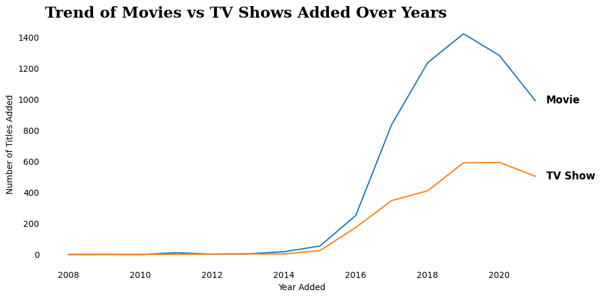

```python
plt.figure(figsize=(10,5))

ax = sns.lineplot(
    data=trend_data,
    x='year_added',
    y='count',
    hue='type'
)

# Remove legend
ax.get_legend().remove()

# Add labels beside lines
for line, label in zip(ax.lines, trend_data['type'].unique()):

    x_data = line.get_xdata()
    y_data = line.get_ydata()

    ax.text(
        x_data[-1] + 0.3,     # slight shift to right
        y_data[-1],
        label,
        fontsize=12,
        fontweight='semibold',
        va='center'
    )

plt.title("Trend of Movies vs TV Shows Added Over Years",
          fontsize=18,
          fontweight='semibold',
          fontfamily='serif',
          loc='left')

plt.xlabel("Year Added")
plt.ylabel("Number of Titles Added")

sns.despine(left=True, bottom=True)
plt.tick_params(left=False, bottom=False)

plt.tight_layout()
plt.show()
```

## We will perform analytics on Movies data and tv shows data seperately for better understanding.

```python
# Movies data
movies_df = df[df['type'] == 'Movie']

# TV shows data
tv_df = df[df['type'] == 'TV Show']
```

### Movies Dataframe

```python
movies_df
```

|  | show_id | type | title | director | cast | country | date_added | release_year | rating | duration | listed_in | description |
| --- | --- | --- | --- | --- | --- | --- | --- | --- | --- | --- | --- | --- |
| 0 | s1 | Movie | Dick Johnson Is Dead | Kirsten Johnson | NaN | United States | September 25, 2021 | 2020 | PG-13 | 90 min | Documentaries | As her father nears the end of his life, filmm... |
| 6 | s7 | Movie | My Little Pony: A New Generation | Robert Cullen, José Luis Ucha | Vanessa Hudgens, Kimiko Glenn, James Marsden, ... | NaN | September 24, 2021 | 2021 | PG | 91 min | Children & Family Movies | Equestria's divided. But a bright-eyed hero be... |
| 7 | s8 | Movie | Sankofa | Haile Gerima | Kofi Ghanaba, Oyafunmike Ogunlano, Alexandra D... | United States, Ghana, Burkina Faso, United Kin... | September 24, 2021 | 1993 | TV-MA | 125 min | Dramas, Independent Movies, International Movies | On a photo shoot in Ghana, an American model s... |
| 9 | s10 | Movie | The Starling | Theodore Melfi | Melissa McCarthy, Chris O'Dowd, Kevin Kline, T... | United States | September 24, 2021 | 2021 | PG-13 | 104 min | Comedies, Dramas | A woman adjusting to life after a loss contend... |
| 12 | s13 | Movie | Je Suis Karl | Christian Schwochow | Luna Wedler, Jannis Niewöhner, Milan Peschel, ... | Germany, Czech Republic | September 23, 2021 | 2021 | TV-MA | 127 min | Dramas, International Movies | After most of her family is murdered in a terr... |
| ... | ... | ... | ... | ... | ... | ... | ... | ... | ... | ... | ... | ... |
| 8801 | s8802 | Movie | Zinzana | Majid Al Ansari | Ali Suliman, Saleh Bakri, Yasa, Ali Al-Jabri, ... | United Arab Emirates, Jordan | March 9, 2016 | 2015 | TV-MA | 96 min | Dramas, International Movies, Thrillers | Recovering alcoholic Talal wakes up inside a s... |
| 8802 | s8803 | Movie | Zodiac | David Fincher | Mark Ruffalo, Jake Gyllenhaal, Robert Downey J... | United States | November 20, 2019 | 2007 | R | 158 min | Cult Movies, Dramas, Thrillers | A political cartoonist, a crime reporter and a... |
| 8804 | s8805 | Movie | Zombieland | Ruben Fleischer | Jesse Eisenberg, Woody Harrelson, Emma Stone, ... | United States | November 1, 2019 | 2009 | R | 88 min | Comedies, Horror Movies | Looking to survive in a world taken over by zo... |
| 8805 | s8806 | Movie | Zoom | Peter Hewitt | Tim Allen, Courteney Cox, Chevy Chase, Kate Ma... | United States | January 11, 2020 | 2006 | PG | 88 min | Children & Family Movies, Comedies | Dragged from civilian life, a former superhero... |
| 8806 | s8807 | Movie | Zubaan | Mozez Singh | Vicky Kaushal, Sarah-Jane Dias, Raaghav Chanan... | India | March 2, 2019 | 2015 | TV-14 | 111 min | Dramas, International Movies, Music & Musicals | A scrappy but poor boy worms his way into a ty... |

6131 rows × 12 columns

```python
movies_df.info()
```

```
<class 'pandas.core.frame.DataFrame'>
Index: 6131 entries, 0 to 8806
Data columns (total 12 columns):
 #   Column        Non-Null Count  Dtype
---  ------        --------------  -----
 0   show_id       6131 non-null   object
 1   type          6131 non-null   object
 2   title         6131 non-null   object
 3   director      5943 non-null   object
 4   cast          5656 non-null   object
 5   country       5691 non-null   object
 6   date_added    6131 non-null   object
 7   release_year  6131 non-null   int64
 8   rating        6129 non-null   object
 9   duration      6128 non-null   object
 10  listed_in     6131 non-null   object
 11  description   6131 non-null   object
dtypes: int64(1), object(11)
memory usage: 751.7+ KB
```

### Dropping not available directors, durations, audience_allowed(rating) rows will be eliminated as they are very less compared to entire data and it wont cause any issue with respect to our concern of the analysis.

```python
movies_df = movies_df.dropna(subset='director')
movies_df = movies_df.dropna(subset=['duration', 'rating'])
```

```python
movies_df.info()
```

```
<class 'pandas.core.frame.DataFrame'>
Index: 5939 entries, 0 to 8806
Data columns (total 12 columns):
 #   Column        Non-Null Count  Dtype
---  ------        --------------  -----
 0   show_id       5939 non-null   object
 1   type          5939 non-null   object
 2   title         5939 non-null   object
 3   director      5939 non-null   object
 4   cast          5518 non-null   object
 5   country       5558 non-null   object
 6   date_added    5939 non-null   object
 7   release_year  5939 non-null   int64
 8   rating        5939 non-null   object
 9   duration      5939 non-null   object
 10  listed_in     5939 non-null   object
 11  description   5939 non-null   object
dtypes: int64(1), object(11)
memory usage: 603.2+ KB
```

Cast column is not related to problem of determining succesfull genres in Tv shows, and movies. So eliminating the entire column

```python
movies_df = movies_df.drop("cast", axis=1)
```

```python
movies_df.info()
```

```
<class 'pandas.core.frame.DataFrame'>
Index: 5939 entries, 0 to 8806
Data columns (total 11 columns):
 #   Column        Non-Null Count  Dtype
---  ------        --------------  -----
 0   show_id       5939 non-null   object
 1   type          5939 non-null   object
 2   title         5939 non-null   object
 3   director      5939 non-null   object
 4   country       5558 non-null   object
 5   date_added    5939 non-null   object
 6   release_year  5939 non-null   int64
 7   rating        5939 non-null   object
 8   duration      5939 non-null   object
 9   listed_in     5939 non-null   object
 10  description   5939 non-null   object
dtypes: int64(1), object(10)
memory usage: 556.8+ KB
```

For the country column there are multiple countries for some movies. So we will convert it into a list.

```python
# Filling the nan values with "" to be able to convert into lists later.
movies_df['country'] = movies_df['country'].fillna('')
```

Missing values are Handled. Lets look for duplicates.

```python
movies_df.duplicated().sum()
```

```
np.int64(0)
```

```python
movies_df["country"] = movies_df['country'].apply(
    lambda x: [country.strip() for country in x.split(',')] if x else []
)
```

```python
movies_df.info()
```

```
<class 'pandas.core.frame.DataFrame'>
Index: 5939 entries, 0 to 8806
Data columns (total 11 columns):
 #   Column        Non-Null Count  Dtype
---  ------        --------------  -----
 0   show_id       5939 non-null   object
 1   type          5939 non-null   object
 2   title         5939 non-null   object
 3   director      5939 non-null   object
 4   country       5939 non-null   object
 5   date_added    5939 non-null   object
 6   release_year  5939 non-null   int64
 7   rating        5939 non-null   object
 8   duration      5939 non-null   object
 9   listed_in     5939 non-null   object
 10  description   5939 non-null   object
dtypes: int64(1), object(10)
memory usage: 556.8+ KB
```

No Duplicated entries are found. But there are some inconsistencies in column data types.

```python
movies_df.head(10)
```

|  | show_id | type | title | director | country | date_added | release_year | rating | duration | listed_in | description |
| --- | --- | --- | --- | --- | --- | --- | --- | --- | --- | --- | --- |
| 0 | s1 | Movie | Dick Johnson Is Dead | Kirsten Johnson | [United States] | September 25, 2021 | 2020 | PG-13 | 90 min | Documentaries | As her father nears the end of his life, filmm... |
| 6 | s7 | Movie | My Little Pony: A New Generation | Robert Cullen, José Luis Ucha | [] | September 24, 2021 | 2021 | PG | 91 min | Children & Family Movies | Equestria's divided. But a bright-eyed hero be... |
| 7 | s8 | Movie | Sankofa | Haile Gerima | [United States, Ghana, Burkina Faso, United Ki... | September 24, 2021 | 1993 | TV-MA | 125 min | Dramas, Independent Movies, International Movies | On a photo shoot in Ghana, an American model s... |
| 9 | s10 | Movie | The Starling | Theodore Melfi | [United States] | September 24, 2021 | 2021 | PG-13 | 104 min | Comedies, Dramas | A woman adjusting to life after a loss contend... |
| 12 | s13 | Movie | Je Suis Karl | Christian Schwochow | [Germany, Czech Republic] | September 23, 2021 | 2021 | TV-MA | 127 min | Dramas, International Movies | After most of her family is murdered in a terr... |
| 13 | s14 | Movie | Confessions of an Invisible Girl | Bruno Garotti | [] | September 22, 2021 | 2021 | TV-PG | 91 min | Children & Family Movies, Comedies | When the clever but socially-awkward Tetê join... |
| 16 | s17 | Movie | Europe's Most Dangerous Man: Otto Skorzeny in ... | Pedro de Echave García, Pablo Azorín Williams | [] | September 22, 2021 | 2020 | TV-MA | 67 min | Documentaries, International Movies | Declassified documents reveal the post-WWII li... |
| 18 | s19 | Movie | Intrusion | Adam Salky | [] | September 22, 2021 | 2021 | TV-14 | 94 min | Thrillers | After a deadly home invasion at a couple’s new... |
| 22 | s23 | Movie | Avvai Shanmughi | K.S. Ravikumar | [] | September 21, 2021 | 1996 | TV-PG | 161 min | Comedies, International Movies | Newly divorced and denied visitation rights wi... |
| 23 | s24 | Movie | Go! Go! Cory Carson: Chrissy Takes the Wheel | Alex Woo, Stanley Moore | [] | September 21, 2021 | 2021 | TV-Y | 61 min | Children & Family Movies | From arcade games to sled days and hiccup cure... |

The date_added column must be corrected.

```python
movies_df['date_added'] = movies_df['date_added'].str.strip(" ")
movies_df['date_added'] = pd.to_datetime(movies_df['date_added'], format="%B %d, %Y")
```

```python
movies_df
```

|  | show_id | type | title | director | country | date_added | release_year | rating | duration | listed_in | description |
| --- | --- | --- | --- | --- | --- | --- | --- | --- | --- | --- | --- |
| 0 | s1 | Movie | Dick Johnson Is Dead | Kirsten Johnson | [United States] | 2021-09-25 | 2020 | PG-13 | 90 min | Documentaries | As her father nears the end of his life, filmm... |
| 6 | s7 | Movie | My Little Pony: A New Generation | Robert Cullen, José Luis Ucha | [] | 2021-09-24 | 2021 | PG | 91 min | Children & Family Movies | Equestria's divided. But a bright-eyed hero be... |
| 7 | s8 | Movie | Sankofa | Haile Gerima | [United States, Ghana, Burkina Faso, United Ki... | 2021-09-24 | 1993 | TV-MA | 125 min | Dramas, Independent Movies, International Movies | On a photo shoot in Ghana, an American model s... |
| 9 | s10 | Movie | The Starling | Theodore Melfi | [United States] | 2021-09-24 | 2021 | PG-13 | 104 min | Comedies, Dramas | A woman adjusting to life after a loss contend... |
| 12 | s13 | Movie | Je Suis Karl | Christian Schwochow | [Germany, Czech Republic] | 2021-09-23 | 2021 | TV-MA | 127 min | Dramas, International Movies | After most of her family is murdered in a terr... |
| ... | ... | ... | ... | ... | ... | ... | ... | ... | ... | ... | ... |
| 8801 | s8802 | Movie | Zinzana | Majid Al Ansari | [United Arab Emirates, Jordan] | 2016-03-09 | 2015 | TV-MA | 96 min | Dramas, International Movies, Thrillers | Recovering alcoholic Talal wakes up inside a s... |
| 8802 | s8803 | Movie | Zodiac | David Fincher | [United States] | 2019-11-20 | 2007 | R | 158 min | Cult Movies, Dramas, Thrillers | A political cartoonist, a crime reporter and a... |
| 8804 | s8805 | Movie | Zombieland | Ruben Fleischer | [United States] | 2019-11-01 | 2009 | R | 88 min | Comedies, Horror Movies | Looking to survive in a world taken over by zo... |
| 8805 | s8806 | Movie | Zoom | Peter Hewitt | [United States] | 2020-01-11 | 2006 | PG | 88 min | Children & Family Movies, Comedies | Dragged from civilian life, a former superhero... |
| 8806 | s8807 | Movie | Zubaan | Mozez Singh | [India] | 2019-03-02 | 2015 | TV-14 | 111 min | Dramas, International Movies, Music & Musicals | A scrappy but poor boy worms his way into a ty... |

5939 rows × 11 columns

The Duration column must also be modified so that the its values can be usable.

```python
movies_df['duration'] = movies_df['duration'].str.extract("(\d+)").astype(int)
```

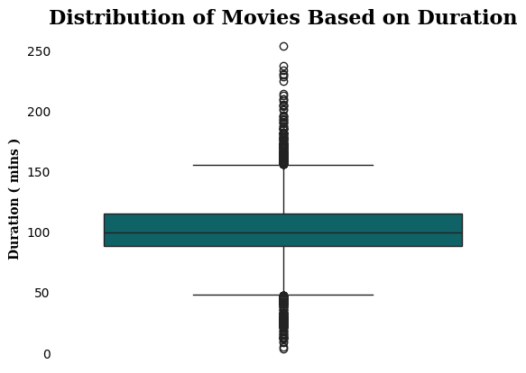

```python
# Outliers check
ax = sns.boxplot(y=movies_df['duration'], color="#007074")

sns.despine(left=True, bottom=True)
ax.tick_params(left=False, bottom=False)

plt.title(
    "Distribution of Movies Based on Duration",
    fontsize=16,
    fontweight='semibold',
    fontfamily='serif'
)

plt.ylabel(
    "Duration ( mins )",
    fontsize=10,
    fontweight='semibold',
    fontfamily='serif'
)

plt.show()
```

- We can understand that 75% of the data is between the duration 50 mins to 150 mins.
- The outliers like movies with more than 150 mins and some less than 50 mins of duration exist but they are very rare.
- The median falls between 85 mins to 115 mins approximately. This can be the most reliable movie duration in terms of production priority.
- The rest of the columns are categorical so there wont be any boxplot usage for them.

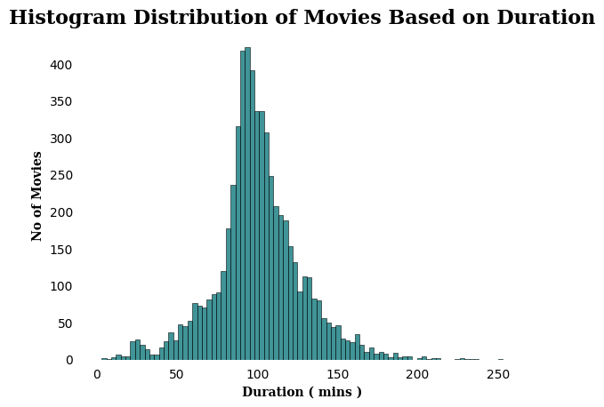

```python
ax = sns.histplot(
    data=movies_df,
    x="duration",
    color='#007074'
)

plt.title(
    "Histogram Distribution of Movies Based on Duration",
    fontsize=16,
    fontweight='semibold',
    fontfamily='serif'
)

plt.xlabel(
    "Duration ( mins )",
    fontsize=10,
    fontweight='semibold',
    fontfamily='serif'
)

plt.ylabel(
    "No of Movies",
    fontsize=10,
    fontweight='semibold',
    fontfamily='serif'
)

sns.despine(left=True, bottom=True)
ax.tick_params(left=False, bottom=False)

plt.show()
```

- Same insights can be infered here as the previous boxplot.

```python
movies_df.info()
```

```
<class 'pandas.core.frame.DataFrame'>
Index: 5939 entries, 0 to 8806
Data columns (total 11 columns):
 #   Column        Non-Null Count  Dtype
---  ------        --------------  -----
 0   show_id       5939 non-null   object
 1   type          5939 non-null   object
 2   title         5939 non-null   object
 3   director      5939 non-null   object
 4   country       5939 non-null   object
 5   date_added    5939 non-null   datetime64[ns]
 6   release_year  5939 non-null   int64
 7   rating        5939 non-null   object
 8   duration      5939 non-null   int64
 9   listed_in     5939 non-null   object
 10  description   5939 non-null   object
dtypes: datetime64[ns](1), int64(2), object(8)
memory usage: 685.8+ KB
```

```python
movies_df.head(10)
```

|  | show_id | type | title | director | country | date_added | release_year | rating | duration | listed_in | description |
| --- | --- | --- | --- | --- | --- | --- | --- | --- | --- | --- | --- |
| 0 | s1 | Movie | Dick Johnson Is Dead | Kirsten Johnson | [United States] | 2021-09-25 | 2020 | PG-13 | 90 | Documentaries | As her father nears the end of his life, filmm... |
| 6 | s7 | Movie | My Little Pony: A New Generation | Robert Cullen, José Luis Ucha | [] | 2021-09-24 | 2021 | PG | 91 | Children & Family Movies | Equestria's divided. But a bright-eyed hero be... |
| 7 | s8 | Movie | Sankofa | Haile Gerima | [United States, Ghana, Burkina Faso, United Ki... | 2021-09-24 | 1993 | TV-MA | 125 | Dramas, Independent Movies, International Movies | On a photo shoot in Ghana, an American model s... |
| 9 | s10 | Movie | The Starling | Theodore Melfi | [United States] | 2021-09-24 | 2021 | PG-13 | 104 | Comedies, Dramas | A woman adjusting to life after a loss contend... |
| 12 | s13 | Movie | Je Suis Karl | Christian Schwochow | [Germany, Czech Republic] | 2021-09-23 | 2021 | TV-MA | 127 | Dramas, International Movies | After most of her family is murdered in a terr... |
| 13 | s14 | Movie | Confessions of an Invisible Girl | Bruno Garotti | [] | 2021-09-22 | 2021 | TV-PG | 91 | Children & Family Movies, Comedies | When the clever but socially-awkward Tetê join... |
| 16 | s17 | Movie | Europe's Most Dangerous Man: Otto Skorzeny in ... | Pedro de Echave García, Pablo Azorín Williams | [] | 2021-09-22 | 2020 | TV-MA | 67 | Documentaries, International Movies | Declassified documents reveal the post-WWII li... |
| 18 | s19 | Movie | Intrusion | Adam Salky | [] | 2021-09-22 | 2021 | TV-14 | 94 | Thrillers | After a deadly home invasion at a couple’s new... |
| 22 | s23 | Movie | Avvai Shanmughi | K.S. Ravikumar | [] | 2021-09-21 | 1996 | TV-PG | 161 | Comedies, International Movies | Newly divorced and denied visitation rights wi... |
| 23 | s24 | Movie | Go! Go! Cory Carson: Chrissy Takes the Wheel | Alex Woo, Stanley Moore | [] | 2021-09-21 | 2021 | TV-Y | 61 | Children & Family Movies | From arcade games to sled days and hiccup cure... |

Lets categorize the movies in terms of duration, so that it will be helpful in analysis.

```python
# Defining a function

def categorizer(row):
  if row['duration'] < 80:
    return 'Short Film'
  elif 80 <= row['duration'] <= 120:
    return 'Standard Film'
  elif 121 <= row['duration'] <= 150:
    return 'Long Film'
  else:
    return 'Epic Film'

movies_df['duration_category'] = movies_df.apply(lambda row: categorizer(row), axis=1)

# We can use np.select here as well for faster performance and vectorized operations.
```

```python
movies_df
```

|  | show_id | type | title | director | country | date_added | release_year | rating | duration | listed_in | description | duration_category |
| --- | --- | --- | --- | --- | --- | --- | --- | --- | --- | --- | --- | --- |
| 0 | s1 | Movie | Dick Johnson Is Dead | Kirsten Johnson | [United States] | 2021-09-25 | 2020 | PG-13 | 90 | Documentaries | As her father nears the end of his life, filmm... | Standard Film |
| 6 | s7 | Movie | My Little Pony: A New Generation | Robert Cullen, José Luis Ucha | [] | 2021-09-24 | 2021 | PG | 91 | Children & Family Movies | Equestria's divided. But a bright-eyed hero be... | Standard Film |
| 7 | s8 | Movie | Sankofa | Haile Gerima | [United States, Ghana, Burkina Faso, United Ki... | 2021-09-24 | 1993 | TV-MA | 125 | Dramas, Independent Movies, International Movies | On a photo shoot in Ghana, an American model s... | Long Film |
| 9 | s10 | Movie | The Starling | Theodore Melfi | [United States] | 2021-09-24 | 2021 | PG-13 | 104 | Comedies, Dramas | A woman adjusting to life after a loss contend... | Standard Film |
| 12 | s13 | Movie | Je Suis Karl | Christian Schwochow | [Germany, Czech Republic] | 2021-09-23 | 2021 | TV-MA | 127 | Dramas, International Movies | After most of her family is murdered in a terr... | Long Film |
| ... | ... | ... | ... | ... | ... | ... | ... | ... | ... | ... | ... | ... |
| 8801 | s8802 | Movie | Zinzana | Majid Al Ansari | [United Arab Emirates, Jordan] | 2016-03-09 | 2015 | TV-MA | 96 | Dramas, International Movies, Thrillers | Recovering alcoholic Talal wakes up inside a s... | Standard Film |
| 8802 | s8803 | Movie | Zodiac | David Fincher | [United States] | 2019-11-20 | 2007 | R | 158 | Cult Movies, Dramas, Thrillers | A political cartoonist, a crime reporter and a... | Epic Film |
| 8804 | s8805 | Movie | Zombieland | Ruben Fleischer | [United States] | 2019-11-01 | 2009 | R | 88 | Comedies, Horror Movies | Looking to survive in a world taken over by zo... | Standard Film |
| 8805 | s8806 | Movie | Zoom | Peter Hewitt | [United States] | 2020-01-11 | 2006 | PG | 88 | Children & Family Movies, Comedies | Dragged from civilian life, a former superhero... | Standard Film |
| 8806 | s8807 | Movie | Zubaan | Mozez Singh | [India] | 2019-03-02 | 2015 | TV-14 | 111 | Dramas, International Movies, Music & Musicals | A scrappy but poor boy worms his way into a ty... | Standard Film |

5939 rows × 12 columns

In order to get proper information on genres. We must convert the listed_in column values into lists.

```python
movies_df['listed_in'].isna().sum()
```

```
np.int64(0)
```

```python
movies_df['listed_in'] = movies_df['listed_in'].apply(
    lambda x: [genre.strip() for genre in x.split(",")] if x else []
)
```

```python
movies_df
```

|  | show_id | type | title | director | country | date_added | release_year | rating | duration | listed_in | description | duration_category |
| --- | --- | --- | --- | --- | --- | --- | --- | --- | --- | --- | --- | --- |
| 0 | s1 | Movie | Dick Johnson Is Dead | Kirsten Johnson | [United States] | 2021-09-25 | 2020 | PG-13 | 90 | [Documentaries] | As her father nears the end of his life, filmm... | Standard Film |
| 6 | s7 | Movie | My Little Pony: A New Generation | Robert Cullen, José Luis Ucha | [] | 2021-09-24 | 2021 | PG | 91 | [Children & Family Movies] | Equestria's divided. But a bright-eyed hero be... | Standard Film |
| 7 | s8 | Movie | Sankofa | Haile Gerima | [United States, Ghana, Burkina Faso, United Ki... | 2021-09-24 | 1993 | TV-MA | 125 | [Dramas, Independent Movies, International Mov... | On a photo shoot in Ghana, an American model s... | Long Film |
| 9 | s10 | Movie | The Starling | Theodore Melfi | [United States] | 2021-09-24 | 2021 | PG-13 | 104 | [Comedies, Dramas] | A woman adjusting to life after a loss contend... | Standard Film |
| 12 | s13 | Movie | Je Suis Karl | Christian Schwochow | [Germany, Czech Republic] | 2021-09-23 | 2021 | TV-MA | 127 | [Dramas, International Movies] | After most of her family is murdered in a terr... | Long Film |
| ... | ... | ... | ... | ... | ... | ... | ... | ... | ... | ... | ... | ... |
| 8801 | s8802 | Movie | Zinzana | Majid Al Ansari | [United Arab Emirates, Jordan] | 2016-03-09 | 2015 | TV-MA | 96 | [Dramas, International Movies, Thrillers] | Recovering alcoholic Talal wakes up inside a s... | Standard Film |
| 8802 | s8803 | Movie | Zodiac | David Fincher | [United States] | 2019-11-20 | 2007 | R | 158 | [Cult Movies, Dramas, Thrillers] | A political cartoonist, a crime reporter and a... | Epic Film |
| 8804 | s8805 | Movie | Zombieland | Ruben Fleischer | [United States] | 2019-11-01 | 2009 | R | 88 | [Comedies, Horror Movies] | Looking to survive in a world taken over by zo... | Standard Film |
| 8805 | s8806 | Movie | Zoom | Peter Hewitt | [United States] | 2020-01-11 | 2006 | PG | 88 | [Children & Family Movies, Comedies] | Dragged from civilian life, a former superhero... | Standard Film |
| 8806 | s8807 | Movie | Zubaan | Mozez Singh | [India] | 2019-03-02 | 2015 | TV-14 | 111 | [Dramas, International Movies, Music & Musicals] | A scrappy but poor boy worms his way into a ty... | Standard Film |

5939 rows × 12 columns

```python
def simplify_rating(rating):
    if rating in ['G', 'TV-G']:
        return 'General'
    elif rating in ['PG', 'TV-PG', 'PG-13']:
        return 'Parental Guidance'
    elif rating in ['TV-14']:
        return '14+'
    elif rating in ['R', 'NC-17', 'TV-MA']:
        return '17+'
    elif rating in ['NR', 'UR']:
        return 'Not Rated'
    else:
        return 'Unknown'

movies_df['rating_category'] = movies_df['rating'].apply(simplify_rating)
```

```python
movies_df['rating_category'].info()
```

```
<class 'pandas.core.series.Series'>
Index: 5939 entries, 0 to 8806
Series name: rating_category
Non-Null Count  Dtype
--------------  -----
5939 non-null   object
dtypes: object(1)
memory usage: 221.8+ KB
```

```python
movies_df['rating_category'].value_counts()
```

| rating_category | count |
| --- | --- |
| 17+ | 2789 |
| 14+ | 1393 |
| Parental Guidance | 1292 |
| Unknown | 232 |
| General | 155 |
| Not Rated | 78 |

**dtype:** int64

```python
# Final analytics ready movies dataframe is

movies_df = movies_df[['title', 'director', 'country', 'date_added', 'release_year', 'rating_category', 'listed_in', 'duration_category']]

# The country and listed_in columns will be used accordingly during analysis.
```

```python
movies_df
```

|  | title | director | country | date_added | release_year | rating_category | listed_in | duration_category |
| --- | --- | --- | --- | --- | --- | --- | --- | --- |
| 0 | Dick Johnson Is Dead | Kirsten Johnson | [United States] | 2021-09-25 | 2020 | Parental Guidance | [Documentaries] | Standard Film |
| 6 | My Little Pony: A New Generation | Robert Cullen, José Luis Ucha | [] | 2021-09-24 | 2021 | Parental Guidance | [Children & Family Movies] | Standard Film |
| 7 | Sankofa | Haile Gerima | [United States, Ghana, Burkina Faso, United Ki... | 2021-09-24 | 1993 | 17+ | [Dramas, Independent Movies, International Mov... | Long Film |
| 9 | The Starling | Theodore Melfi | [United States] | 2021-09-24 | 2021 | Parental Guidance | [Comedies, Dramas] | Standard Film |
| 12 | Je Suis Karl | Christian Schwochow | [Germany, Czech Republic] | 2021-09-23 | 2021 | 17+ | [Dramas, International Movies] | Long Film |
| ... | ... | ... | ... | ... | ... | ... | ... | ... |
| 8801 | Zinzana | Majid Al Ansari | [United Arab Emirates, Jordan] | 2016-03-09 | 2015 | 17+ | [Dramas, International Movies, Thrillers] | Standard Film |
| 8802 | Zodiac | David Fincher | [United States] | 2019-11-20 | 2007 | 17+ | [Cult Movies, Dramas, Thrillers] | Epic Film |
| 8804 | Zombieland | Ruben Fleischer | [United States] | 2019-11-01 | 2009 | 17+ | [Comedies, Horror Movies] | Standard Film |
| 8805 | Zoom | Peter Hewitt | [United States] | 2020-01-11 | 2006 | Parental Guidance | [Children & Family Movies, Comedies] | Standard Film |
| 8806 | Zubaan | Mozez Singh | [India] | 2019-03-02 | 2015 | 14+ | [Dramas, International Movies, Music & Musicals] | Standard Film |

5939 rows × 8 columns

```python
movies_df.describe().T
```

|  | count | mean | min | 25% | 50% | 75% | max | std |
| --- | --- | --- | --- | --- | --- | --- | --- | --- |
| date_added | 5939 | 2019-05-09 17:46:07.132513792 | 2008-01-01 00:00:00 | 2018-04-03 00:00:00 | 2019-06-20 00:00:00 | 2020-07-24 00:00:00 | 2021-09-25 00:00:00 | NaN |
| release_year | 5939.0 | 2013.009766 | 1942.0 | 2012.0 | 2016.0 | 2018.0 | 2021.0 | 9.752075 |

```python
movies_df.info()
```

```
<class 'pandas.core.frame.DataFrame'>
Index: 5939 entries, 0 to 8806
Data columns (total 8 columns):
 #   Column             Non-Null Count  Dtype
---  ------             --------------  -----
 0   title              5939 non-null   object
 1   director           5939 non-null   object
 2   country            5939 non-null   object
 3   date_added         5939 non-null   datetime64[ns]
 4   release_year       5939 non-null   int64
 5   rating_category    5939 non-null   object
 6   listed_in          5939 non-null   object
 7   duration_category  5939 non-null   object
dtypes: datetime64[ns](1), int64(1), object(6)
memory usage: 546.6+ KB
```

## Data Analysis [ Movies ]

Q1. What Countries Produce highest number of movies ( Top 10 ) ?

```python
country_vs_movies = movies_df[['country', 'title']]
```

```python
country_vs_movies = country_vs_movies.explode('country')
```

```python
country_vs_movies['country'] = country_vs_movies['country'].fillna("Unknown")
```

```python
country_vs_movies.info()
```

```
<class 'pandas.core.frame.DataFrame'>
Index: 7604 entries, 0 to 8806
Data columns (total 2 columns):
 #   Column   Non-Null Count  Dtype
---  ------   --------------  -----
 0   country  7604 non-null   object
 1   title    7604 non-null   object
dtypes: object(2)
memory usage: 178.2+ KB
```

```python
top_15_movie_producing_countries = country_vs_movies.groupby('country')['title'].count().reset_index(name='movie_count').sort_values('movie_count', ascending=False).head(15)
```

```python
top_15_movie_producing_countries['movie_count'].sum()
```

```
np.int64(6204)
```

```python
total_movies = top_15_movie_producing_countries['movie_count'].sum()

top_15_movie_producing_countries['percentage'] = (
    top_15_movie_producing_countries['movie_count'] / total_movies
) * 100
```

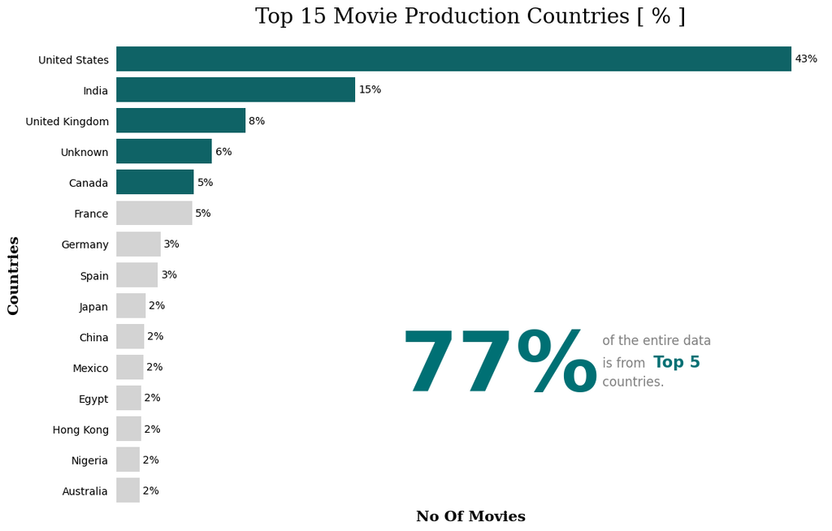

```python
plt.figure(figsize = (12,8))

colors = [
    '#007074' if i < 5 else 'lightgray'
    for i in range(len(top_15_movie_producing_countries))
]


ax = sns.barplot(
    data=top_15_movie_producing_countries,
    x='percentage',
    y='country',
    hue='country',
    palette=colors
)
plt.title("Top 15 Movie Production Countries [ % ]", fontsize=20, pad=20, fontfamily='serif')

plt.ylabel('Countries' , fontweight='bold', fontsize=14, fontfamily='serif')
plt.xlabel('No Of Movies', fontweight='bold', fontsize=14, fontfamily='serif')

sns.despine(left=True, bottom=True)
ax.tick_params(left=False, bottom=False)
ax.set_xticks([])

ax.text(
    0.40, 0.25,                # Position (relative to axes)
    "77%",                     # Main big text
    transform=ax.transAxes,
    fontsize=80,
    fontweight='bold',
    color='#007074'
)

ax.text(
    0.68, 0.35,
    " of the entire data",
    transform=ax.transAxes,
    fontsize=12,
    color='gray'
)

ax.text(
    0.68, 0.30,
    " is from ",
    transform=ax.transAxes,
    fontsize=12,
    color='gray'
)

ax.text(
    0.75, 0.30,
    " Top 5",
    transform=ax.transAxes,
    fontsize=15,
    fontweight='semibold',
    color='#007074'
)

ax.text(
    0.68, 0.26,
    " countries.",
    transform=ax.transAxes,
    fontsize=12,
    color='gray'
)


ax.spines['bottom'].set_visible(False)

plt.tight_layout(pad=4)

for i in ax.containers:
  ax.bar_label(i, fmt="{:,.0f}%", padding=3 )

plt.show()
```

### Insights:

1. Netflix can implement and encourage mid-budget movie production both in english and in Regional language for more audience involvement.
2. Compared to the rest the European Countries which are FRANCE, INDIA and UK and also the Asian contries which are JAPAN and CHINA can be converted to tier-1 countries if Netflix expand and invest in localized original movie production in those countries especially specially for more performing genres.
3. The United States covers a large share of total movie production. Depending too much on one country can be risky, so expanding production in other regions could help create a more balanced and stable growth strategy.

## Since 80% of the data is from is from top 15 countries, our analysis will be subjected to these countries only.

Q2. What are the top 3 genres for each country ?

```python
# We are required to get the genre wise data for each country.

country_genre_df = movies_df[['country', 'listed_in']]
```

```python
country_genre_df
```

|  | country | listed_in |
| --- | --- | --- |
| 0 | [United States] | [Documentaries] |
| 6 | [] | [Children & Family Movies] |
| 7 | [United States, Ghana, Burkina Faso, United Ki... | [Dramas, Independent Movies, International Mov... |
| 9 | [United States] | [Comedies, Dramas] |
| 12 | [Germany, Czech Republic] | [Dramas, International Movies] |
| ... | ... | ... |
| 8801 | [United Arab Emirates, Jordan] | [Dramas, International Movies, Thrillers] |
| 8802 | [United States] | [Cult Movies, Dramas, Thrillers] |
| 8804 | [United States] | [Comedies, Horror Movies] |
| 8805 | [United States] | [Children & Family Movies, Comedies] |
| 8806 | [India] | [Dramas, International Movies, Music & Musicals] |

5939 rows × 2 columns

```python
country_genre_df = country_genre_df.explode('country')
country_genre_df = country_genre_df.explode('listed_in')
```

```python
country_genre_df.info()
```

```
<class 'pandas.core.frame.DataFrame'>
Index: 16541 entries, 0 to 8806
Data columns (total 2 columns):
 #   Column     Non-Null Count  Dtype
---  ------     --------------  -----
 0   country    15768 non-null  object
 1   listed_in  16541 non-null  object
dtypes: object(2)
memory usage: 387.7+ KB
```

```python
country_genre_df.head(20)
```

|  | country | listed_in |
| --- | --- | --- |
| 0 | United States | Documentaries |
| 6 | NaN | Children & Family Movies |
| 7 | United States | Dramas |
| 7 | United States | Independent Movies |
| 7 | United States | International Movies |
| 7 | Ghana | Dramas |
| 7 | Ghana | Independent Movies |
| 7 | Ghana | International Movies |
| 7 | Burkina Faso | Dramas |
| 7 | Burkina Faso | Independent Movies |
| 7 | Burkina Faso | International Movies |
| 7 | United Kingdom | Dramas |
| 7 | United Kingdom | Independent Movies |
| 7 | United Kingdom | International Movies |
| 7 | Germany | Dramas |
| 7 | Germany | Independent Movies |
| 7 | Germany | International Movies |
| 7 | Ethiopia | Dramas |
| 7 | Ethiopia | Independent Movies |
| 7 | Ethiopia | International Movies |

```python
top_15_countries = top_15_movie_producing_countries['country']
```

```python
top_15_countries
```

|  | country |
| --- | --- |
| 111 | United States |
| 42 | India |
| 110 | United Kingdom |
| 112 | Unknown |
| 19 | Canada |
| 33 | France |
| 35 | Germany |
| 98 | Spain |
| 50 | Japan |
| 22 | China |
| 64 | Mexico |
| 30 | Egypt |
| 39 | Hong Kong |
| 74 | Nigeria |
| 7 | Australia |

**dtype:** object

```python
filtered_df = country_genre_df[
    country_genre_df['country'].isin(top_15_countries)
]
```

```python
top3_genres_top15 = (
    filtered_df
    .groupby(['country', 'listed_in'])
    .size()
    .reset_index(name='count')
    .assign(rank=lambda x: x.groupby('country')['count']
            .rank(method='first', ascending=False))
    .query('rank <= 3')
    .sort_values(['country', 'rank'])
)
```

```python
top3_genres_top15.head()
```

|  | country | listed_in | count | rank |
| --- | --- | --- | --- | --- |
| 6 | Australia | Dramas | 38 | 1.0 |
| 10 | Australia | International Movies | 30 | 2.0 |
| 1 | Australia | Children & Family Movies | 19 | 3.0 |
| 21 | Canada | Comedies | 94 | 1.0 |
| 24 | Canada | Dramas | 81 | 2.0 |

```python
top3_genres_top15['percentage'] = (
    top3_genres_top15
    .groupby('country')['count']
    .transform(lambda x: x / x.sum() * 100)
)
```

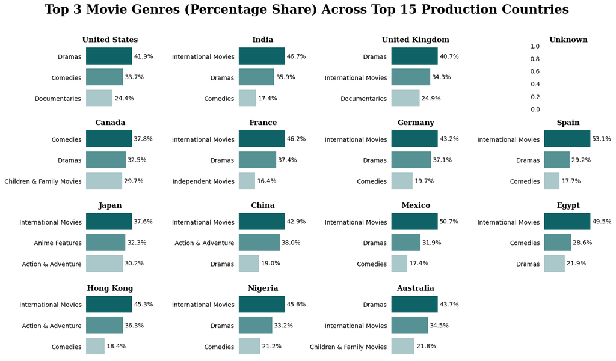

```python
# Get unique countries
countries = (
    top_15_movie_producing_countries
    .sort_values('percentage', ascending=False)['country']
    .values
)

n_cols = 4
n_rows = int(np.ceil(len(countries) / n_cols))

fig, axes = plt.subplots(n_rows, n_cols, figsize=(14, 2 * n_rows))
axes = axes.flatten()

for i, country in enumerate(countries):

    data = (
        top3_genres_top15[
            top3_genres_top15['country'] == country
        ]
        .sort_values('percentage', ascending=False)
    )

    colors = ['#007074', '#4C9A9D', '#A5CCCE']

    sns.barplot(
        data=data,
        x='percentage',     # 🔥 changed from count
        y='listed_in',
        hue='listed_in',
        legend=False,
        ax=axes[i],
        palette=colors
    )

    axes[i].set_title(country,
                      fontsize=12,
                      fontweight='bold',
                      fontfamily='serif')

    axes[i].set_xlabel('')
    axes[i].set_ylabel('')
    axes[i].set_xticks([])

    sns.despine(ax=axes[i], left=True, bottom=True)
    axes[i].tick_params(left=False, bottom=False)

    # Add percentage labels
    for container in axes[i].containers:
        axes[i].bar_label(container,
                          fmt="%.1f%%",
                          padding=3)

# Hide unused subplots safely
for ax in axes[len(countries):]:
    ax.set_visible(False)

plt.suptitle(
    "Top 3 Movie Genres (Percentage Share) Across Top 15 Production Countries",
    fontsize=20,
    fontweight='bold',
    y=1.02,
    fontfamily="serif"
)

plt.tight_layout()
plt.show()
```

From the perspective of Movies - Dramas and Comedies are found out to be the most popular globally.

Q3. What are the top3 ratings in the top 15 performing countries ?

```python
movies_df.columns
```

```
Index(['title', 'director', 'country', 'date_added', 'release_year',
       'rating_category', 'listed_in', 'duration_category'],
      dtype='object')
```

```python
country_vs_rating = movies_df[['country', 'rating_category']]
country_vs_rating = country_vs_rating.explode('country')
```

```python
top15_country_vs_rating = country_vs_rating[country_vs_rating['country'].isin(top_15_countries)]
```

```python
top15_country_vs_rating = top15_country_vs_rating.groupby(['country', 'rating_category'])['rating_category'].count().sort_values(ascending=False).reset_index(name='category_count')
```

```python
top15_country_vs_rating
```

|  | country | rating_category | category_count |
| --- | --- | --- | --- |
| 0 | United States | 17+ | 1350 |
| 1 | United States | Parental Guidance | 848 |
| 2 | India | 14+ | 540 |
| 3 | United Kingdom | 17+ | 274 |
| 4 | United States | 14+ | 267 |
| ... | ... | ... | ... |
| 71 | Germany | Not Rated | 2 |
| 72 | Spain | Unknown | 2 |
| 73 | Egypt | General | 1 |
| 74 | Nigeria | Not Rated | 1 |
| 75 | Japan | General | 1 |

76 rows × 3 columns

```python
top15_country_vs_rating['percentage'] = (
    top15_country_vs_rating
    .groupby('country')['category_count']
    .transform(lambda x: x / x.sum() * 100)
)
```

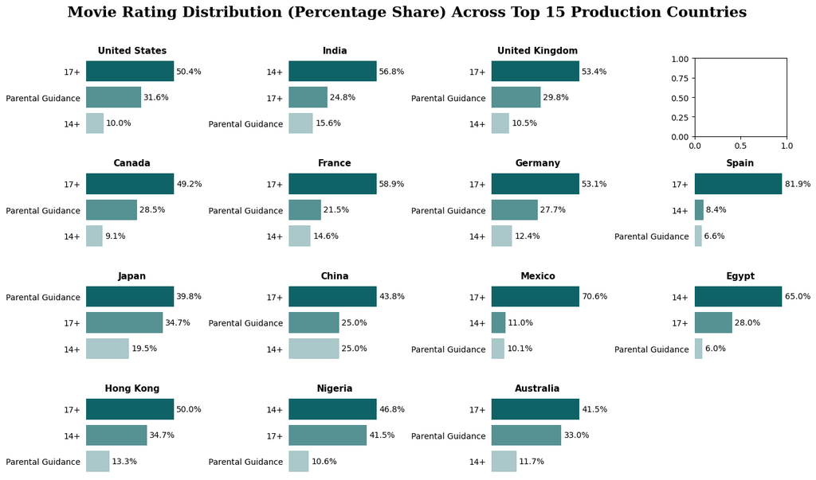

```python
# Ensure countries ordered properly
countries = (
    top_15_movie_producing_countries
    .sort_values('movie_count', ascending=False)['country']
    .values
)

n_cols = 4
n_rows = int(np.ceil(len(countries) / n_cols))

fig, axes = plt.subplots(n_rows, n_cols, figsize=(14, 2 * n_rows))
axes = axes.flatten()

for i, country in enumerate(countries):

    data = (
        top15_country_vs_rating[
            top15_country_vs_rating['country'] == country
        ]
        .sort_values('percentage', ascending=False)
        .head(3)
    )

    if data.empty:
        continue

    base_colors = ['#007074', '#4C9A9D', '#A5CCCE']
    colors = sns.color_palette(base_colors, n_colors=len(data))

    sns.barplot(
        data=data,
        x='percentage',    # 🔥 changed here
        y='rating_category',
        hue='rating_category',
        legend=False,
        ax=axes[i],
        palette=colors
    )

    axes[i].set_title(country, fontsize=11, fontweight='bold')
    axes[i].set_xlabel('')
    axes[i].set_ylabel('')
    axes[i].set_xticks([])

    sns.despine(ax=axes[i], left=True, bottom=True)
    axes[i].tick_params(left=False, bottom=False)

    # Percentage labels
    for container in axes[i].containers:
        axes[i].bar_label(container,
                          fmt="%.1f%%",
                          padding=3)

# Hide unused axes safely
for ax in axes[len(countries):]:
    ax.set_visible(False)

plt.suptitle(
    "Movie Rating Distribution (Percentage Share) Across Top 15 Production Countries",
    fontsize=18,
    fontweight='bold',
    y=1.02,
    fontfamily="serif"
)

plt.tight_layout()
plt.show()
```

Q4. What duration category dominates in each country ?

```python
movies_df
```

|  | title | director | country | date_added | release_year | rating_category | listed_in | duration_category |
| --- | --- | --- | --- | --- | --- | --- | --- | --- |
| 0 | Dick Johnson Is Dead | Kirsten Johnson | [United States] | 2021-09-25 | 2020 | Parental Guidance | [Documentaries] | Standard Film |
| 6 | My Little Pony: A New Generation | Robert Cullen, José Luis Ucha | [] | 2021-09-24 | 2021 | Parental Guidance | [Children & Family Movies] | Standard Film |
| 7 | Sankofa | Haile Gerima | [United States, Ghana, Burkina Faso, United Ki... | 2021-09-24 | 1993 | 17+ | [Dramas, Independent Movies, International Mov... | Long Film |
| 9 | The Starling | Theodore Melfi | [United States] | 2021-09-24 | 2021 | Parental Guidance | [Comedies, Dramas] | Standard Film |
| 12 | Je Suis Karl | Christian Schwochow | [Germany, Czech Republic] | 2021-09-23 | 2021 | 17+ | [Dramas, International Movies] | Long Film |
| ... | ... | ... | ... | ... | ... | ... | ... | ... |
| 8801 | Zinzana | Majid Al Ansari | [United Arab Emirates, Jordan] | 2016-03-09 | 2015 | 17+ | [Dramas, International Movies, Thrillers] | Standard Film |
| 8802 | Zodiac | David Fincher | [United States] | 2019-11-20 | 2007 | 17+ | [Cult Movies, Dramas, Thrillers] | Epic Film |
| 8804 | Zombieland | Ruben Fleischer | [United States] | 2019-11-01 | 2009 | 17+ | [Comedies, Horror Movies] | Standard Film |
| 8805 | Zoom | Peter Hewitt | [United States] | 2020-01-11 | 2006 | Parental Guidance | [Children & Family Movies, Comedies] | Standard Film |
| 8806 | Zubaan | Mozez Singh | [India] | 2019-03-02 | 2015 | 14+ | [Dramas, International Movies, Music & Musicals] | Standard Film |

5939 rows × 8 columns

```python
country_vs_duration = movies_df[['country', 'duration_category']]
country_vs_duration
```

|  | country | duration_category |
| --- | --- | --- |
| 0 | [United States] | Standard Film |
| 6 | [] | Standard Film |
| 7 | [United States, Ghana, Burkina Faso, United Ki... | Long Film |
| 9 | [United States] | Standard Film |
| 12 | [Germany, Czech Republic] | Long Film |
| ... | ... | ... |
| 8801 | [United Arab Emirates, Jordan] | Standard Film |
| 8802 | [United States] | Epic Film |
| 8804 | [United States] | Standard Film |
| 8805 | [United States] | Standard Film |
| 8806 | [India] | Standard Film |

5939 rows × 2 columns

```python
top_15_countries
```

|  | country |
| --- | --- |
| 111 | United States |
| 42 | India |
| 110 | United Kingdom |
| 112 | Unknown |
| 19 | Canada |
| 33 | France |
| 35 | Germany |
| 98 | Spain |
| 50 | Japan |
| 22 | China |
| 64 | Mexico |
| 30 | Egypt |
| 39 | Hong Kong |
| 74 | Nigeria |
| 7 | Australia |

**dtype:** object

```python
country_vs_duration = country_vs_duration.explode('country')
```

```python
country_vs_duration = country_vs_duration[country_vs_duration['country'].isin(top_15_countries)]
country_vs_duration
```

|  | country | duration_category |
| --- | --- | --- |
| 0 | United States | Standard Film |
| 7 | United States | Long Film |
| 7 | United Kingdom | Long Film |
| 7 | Germany | Long Film |
| 9 | United States | Standard Film |
| ... | ... | ... |
| 8799 | India | Standard Film |
| 8802 | United States | Epic Film |
| 8804 | United States | Standard Film |
| 8805 | United States | Standard Film |
| 8806 | India | Standard Film |

5823 rows × 2 columns

```python
country_vs_duration.head()
```

|  | country | duration_category |
| --- | --- | --- |
| 0 | United States | Standard Film |
| 7 | United States | Long Film |
| 7 | United Kingdom | Long Film |
| 7 | Germany | Long Film |
| 9 | United States | Standard Film |

```python
country_vs_duration = country_vs_duration.groupby(['country', 'duration_category'])['duration_category'].count().reset_index(name="movie_count").sort_values(by="movie_count",ascending=False)
```

```python
country_vs_duration.head(10)
```

|  | country | duration_category | movie_count |
| --- | --- | --- | --- |
| 53 | United States | Standard Film | 1894 |
| 52 | United States | Short Film | 504 |
| 27 | India | Long Film | 414 |
| 49 | United Kingdom | Standard Film | 358 |
| 29 | India | Standard Film | 350 |
| 6 | Canada | Standard Film | 248 |
| 51 | United States | Long Film | 242 |
| 17 | France | Standard Film | 239 |
| 26 | India | Epic Film | 154 |
| 45 | Spain | Standard Film | 137 |

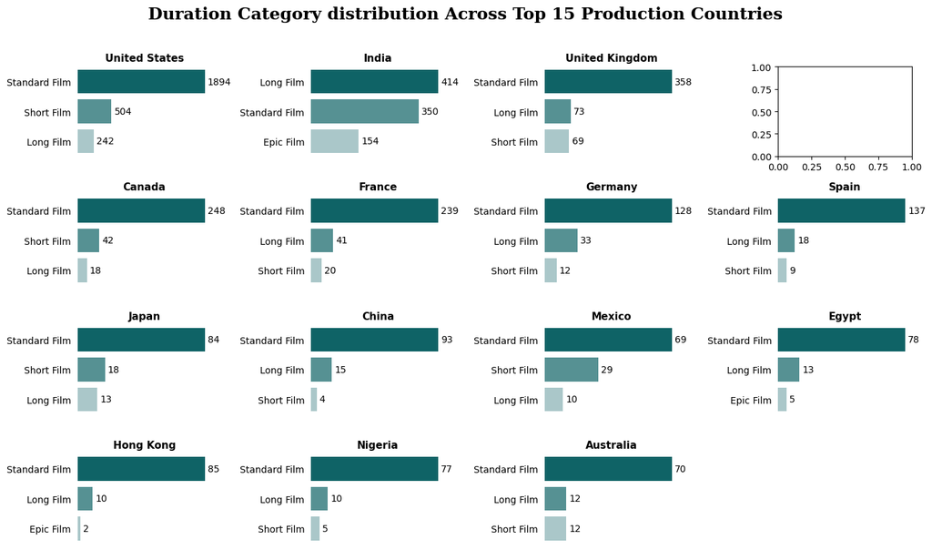

```python
# Ensure countries are ordered properly (same order as production ranking)
countries = (
    top_15_movie_producing_countries
    .sort_values('movie_count', ascending=False)['country']
    .values
)

# Grid layout
n_cols = 4
n_rows = int(np.ceil(len(countries) / n_cols))

fig, axes = plt.subplots(n_rows, n_cols, figsize=(14, 2 * n_rows))
axes = axes.flatten()

for i, country in enumerate(countries):

    # Filter country data
    data = (
        country_vs_duration[country_vs_duration['country'] == country]
        .sort_values('movie_count', ascending=False).head(3)
    )

    if data.empty:
        continue

    # Color palette (darkest for highest)
    base_colors = ['#007074', '#4C9A9D', '#A5CCCE']
    colors = sns.color_palette(base_colors, n_colors=len(data))

    sns.barplot(
        data=data,
        x='movie_count',
        y='duration_category',
        hue='duration_category',
        legend=False,
        ax=axes[i],
        palette=colors
    )

    axes[i].set_title(country, fontsize=11, fontweight='bold')
    axes[i].set_xlabel('')
    axes[i].set_ylabel('')

    sns.despine(ax=axes[i], left=True, bottom=True)

    axes[i].set_xticks([])
    axes[i].tick_params(left=False, bottom=False)

    for container in axes[i].containers:
        axes[i].bar_label(container, fmt='%d', padding=3)

# Remove unused axes
for j in range(i + 1, len(axes)):
    fig.delaxes(axes[j])

plt.suptitle(
    "Duration Category distribution Across Top 15 Production Countries",
    fontsize=18,
    fontweight='bold',
    y=1.02,
    fontfamily="serif"
)

plt.tight_layout()
plt.show()
```

- In almost all top production countries, Standard Films clearly dominate over Short Films and Long/Epic Films. This shows that Netflix mainly focuses on regular-length movies across markets, suggesting that standard duration content is the safest and most preferred format globally.
- Countries like India show a noticeable presence of Long and Epic Films compared to many Western countries. This indicates that some regional markets may have a stronger acceptance for longer storytelling formats, possibly due to cultural viewing habits.
- Short Films and Epic Films are very limited across most countries, which suggests Netflix is not heavily investing in experimental or niche duration formats. For expansion, there may be an opportunity to test more diverse duration categories in selected markets to see if audience preferences evolve.

Q5. What are the top performing genres globally ?

```python
movies_df
```

|  | title | director | country | date_added | release_year | rating_category | listed_in | duration_category |
| --- | --- | --- | --- | --- | --- | --- | --- | --- |
| 0 | Dick Johnson Is Dead | Kirsten Johnson | [United States] | 2021-09-25 | 2020 | Parental Guidance | [Documentaries] | Standard Film |
| 6 | My Little Pony: A New Generation | Robert Cullen, José Luis Ucha | [] | 2021-09-24 | 2021 | Parental Guidance | [Children & Family Movies] | Standard Film |
| 7 | Sankofa | Haile Gerima | [United States, Ghana, Burkina Faso, United Ki... | 2021-09-24 | 1993 | 17+ | [Dramas, Independent Movies, International Mov... | Long Film |
| 9 | The Starling | Theodore Melfi | [United States] | 2021-09-24 | 2021 | Parental Guidance | [Comedies, Dramas] | Standard Film |
| 12 | Je Suis Karl | Christian Schwochow | [Germany, Czech Republic] | 2021-09-23 | 2021 | 17+ | [Dramas, International Movies] | Long Film |
| ... | ... | ... | ... | ... | ... | ... | ... | ... |
| 8801 | Zinzana | Majid Al Ansari | [United Arab Emirates, Jordan] | 2016-03-09 | 2015 | 17+ | [Dramas, International Movies, Thrillers] | Standard Film |
| 8802 | Zodiac | David Fincher | [United States] | 2019-11-20 | 2007 | 17+ | [Cult Movies, Dramas, Thrillers] | Epic Film |
| 8804 | Zombieland | Ruben Fleischer | [United States] | 2019-11-01 | 2009 | 17+ | [Comedies, Horror Movies] | Standard Film |
| 8805 | Zoom | Peter Hewitt | [United States] | 2020-01-11 | 2006 | Parental Guidance | [Children & Family Movies, Comedies] | Standard Film |
| 8806 | Zubaan | Mozez Singh | [India] | 2019-03-02 | 2015 | 14+ | [Dramas, International Movies, Music & Musicals] | Standard Film |

5939 rows × 8 columns

```python
global_genres = (
    movies_df
    .explode('listed_in')
    .groupby('listed_in')
    .size()
    .reset_index(name='count')
    .sort_values(by="count",ascending=False)
    .head(10)
)

global_genres
```

|  | listed_in | count |
| --- | --- | --- |
| 11 | International Movies | 2705 |
| 7 | Dramas | 2401 |
| 4 | Comedies | 1642 |
| 0 | Action & Adventure | 851 |
| 6 | Documentaries | 812 |
| 10 | Independent Movies | 751 |
| 2 | Children & Family Movies | 605 |
| 15 | Romantic Movies | 605 |
| 19 | Thrillers | 575 |
| 14 | Music & Musicals | 358 |

```python
global_genres['percentage'] = (
    global_genres['count'] / global_genres['count'].sum()
) * 100
```

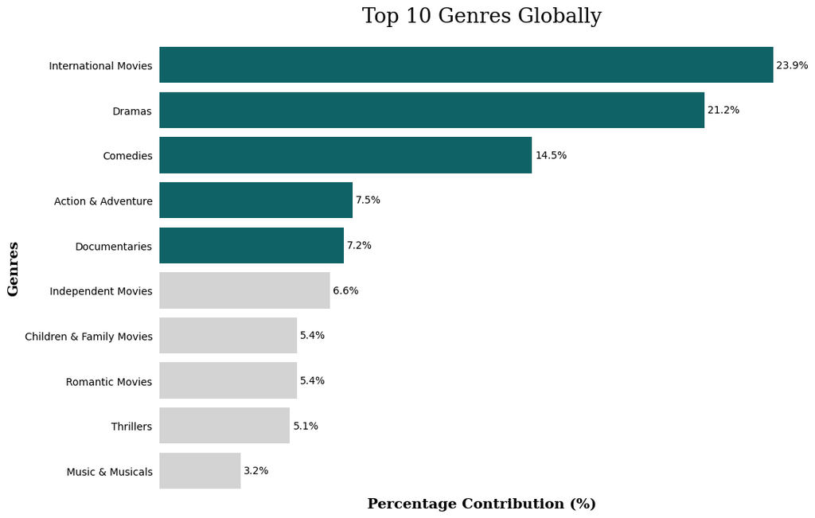

```python
plt.figure(figsize=(12,8))

# Convert to percentage
global_genres['percentage'] = (
    global_genres['count'] / global_genres['count'].sum()
) * 100

colors = [
    '#007074' if i < 5 else 'lightgray'
    for i in range(len(global_genres))
]

ax = sns.barplot(
    data=global_genres,
    x='percentage',   # 🔥 changed here
    y='listed_in',
    hue='listed_in',
    palette=colors
)

plt.title("Top 10 Genres Globally",
          fontsize=20,
          pad=20,
          fontfamily='serif')

plt.ylabel('Genres',
           fontweight='bold',
           fontsize=14,
           fontfamily='serif')

plt.xlabel('Percentage Contribution (%)',
           fontweight='bold',
           fontsize=14,
           fontfamily='serif')

sns.despine(left=True, bottom=True)
ax.tick_params(left=False, bottom=False)
ax.set_xticks([])
ax.spines['bottom'].set_visible(False)

plt.tight_layout(pad=4)

# Percentage labels
for container in ax.containers:
    ax.bar_label(container,
                 fmt="%.1f%%",
                 padding=3)

plt.show()
```

- International Movies clearly dominate globally, followed by Dramas and Comedies. This shows that Netflix strongly focuses on globally adaptable and emotionally engaging content formats, which likely perform well across different cultures and regions.
- After the top three genres, there is a noticeable drop in volume. Genres like Action & Adventure, Documentaries, and Independent Movies have moderate presence, while categories like Thrillers and Music & Musicals are much smaller. This suggests Netflix prioritizes mainstream genres over niche ones.
- Aproximately 75% of the Movies are from top 5 genres Globally.

Q6. Which genres are inceasing in recent release years ?

```python
movies_df.head(10)
```

|  | title | director | country | date_added | release_year | rating_category | listed_in | duration_category |
| --- | --- | --- | --- | --- | --- | --- | --- | --- |
| 0 | Dick Johnson Is Dead | Kirsten Johnson | [United States] | 2021-09-25 | 2020 | Parental Guidance | [Documentaries] | Standard Film |
| 6 | My Little Pony: A New Generation | Robert Cullen, José Luis Ucha | [] | 2021-09-24 | 2021 | Parental Guidance | [Children & Family Movies] | Standard Film |
| 7 | Sankofa | Haile Gerima | [United States, Ghana, Burkina Faso, United Ki... | 2021-09-24 | 1993 | 17+ | [Dramas, Independent Movies, International Mov... | Long Film |
| 9 | The Starling | Theodore Melfi | [United States] | 2021-09-24 | 2021 | Parental Guidance | [Comedies, Dramas] | Standard Film |
| 12 | Je Suis Karl | Christian Schwochow | [Germany, Czech Republic] | 2021-09-23 | 2021 | 17+ | [Dramas, International Movies] | Long Film |
| 13 | Confessions of an Invisible Girl | Bruno Garotti | [] | 2021-09-22 | 2021 | Parental Guidance | [Children & Family Movies, Comedies] | Standard Film |
| 16 | Europe's Most Dangerous Man: Otto Skorzeny in ... | Pedro de Echave García, Pablo Azorín Williams | [] | 2021-09-22 | 2020 | 17+ | [Documentaries, International Movies] | Short Film |
| 18 | Intrusion | Adam Salky | [] | 2021-09-22 | 2021 | 14+ | [Thrillers] | Standard Film |
| 22 | Avvai Shanmughi | K.S. Ravikumar | [] | 2021-09-21 | 1996 | Parental Guidance | [Comedies, International Movies] | Epic Film |
| 23 | Go! Go! Cory Carson: Chrissy Takes the Wheel | Alex Woo, Stanley Moore | [] | 2021-09-21 | 2021 | Unknown | [Children & Family Movies] | Short Film |

```python
year_wise_data = movies_df[['title', 'release_year', 'listed_in']]
```

```python
year_wise_data = year_wise_data.explode('listed_in')
```

```python
year_wise_data = year_wise_data.groupby(["release_year", "listed_in"]).size().reset_index(name='count').sort_values(by='release_year')
```

```python
latest_years_release_data = year_wise_data[year_wise_data['release_year'].between(2010,2021)]
```

```python
latest_years_release_data.sort_values('count', ascending=False)
```

|  | release_year | listed_in | count |
| --- | --- | --- | --- |
| 709 | 2018 | International Movies | 330 |
| 689 | 2017 | International Movies | 321 |
| 670 | 2016 | International Movies | 303 |
| 705 | 2018 | Dramas | 299 |
| 685 | 2017 | Dramas | 284 |
| ... | ... | ... | ... |
| 664 | 2016 | Cult Movies | 1 |
| 701 | 2018 | Classic Movies | 1 |
| 703 | 2018 | Cult Movies | 1 |
| 729 | 2019 | Movies | 1 |
| 749 | 2020 | Sci-Fi & Fantasy | 1 |

218 rows × 3 columns